# Flight Delay Propagation Analysis

This notebook cleans flight data, engineers delay propagation features, performs exploratory data analysis, and produces statistical summaries to understand delay propagation.

## 1. Import Libraries

```python
import pandas as pd
import numpy as np
import matplotlib.pyplot as plt
import seaborn as sns
sns.set_style('whitegrid')
```

```python
pd.set_option('display.max_columns', None)   # show all columns
pd.set_option('display.width', None)         # prevent line wrapping
pd.set_option('display.max_colwidth', None)  # show full column contents
```

## 2. Load Dataset

```python
df = pd.read_csv('flights.csv', low_memory=False)
print(df.shape)
df.head()
```

```
(5819079, 31)
```

|  | YEAR | MONTH | DAY | DAY_OF_WEEK | AIRLINE | FLIGHT_NUMBER | TAIL_NUMBER | ORIGIN_AIRPORT | DESTINATION_AIRPORT | SCHEDULED_DEPARTURE | DEPARTURE_TIME | DEPARTURE_DELAY | TAXI_OUT | WHEELS_OFF | SCHEDULED_TIME | ELAPSED_TIME | AIR_TIME | DISTANCE | WHEELS_ON | TAXI_IN | SCHEDULED_ARRIVAL | ARRIVAL_TIME | ARRIVAL_DELAY | DIVERTED | CANCELLED | CANCELLATION_REASON | AIR_SYSTEM_DELAY | SECURITY_DELAY | AIRLINE_DELAY | … |
| --- | --- | --- | --- | --- | --- | --- | --- | --- | --- | --- | --- | --- | --- | --- | --- | --- | --- | --- | --- | --- | --- | --- | --- | --- | --- | --- | --- | --- | --- | --- |
| 0 | 2015 | 1 | 1 | 4 | AS | 98 | N407AS | ANC | SEA | 5 | 2354.0 | -11.0 | 21.0 | 15.0 | 205.0 | 194.0 | 169.0 | 1448 | 404.0 | 4.0 | 430 | 408.0 | -22.0 | 0 | 0 | NaN | NaN | NaN | NaN | … |
| 1 | 2015 | 1 | 1 | 4 | AA | 2336 | N3KUAA | LAX | PBI | 10 | 2.0 | -8.0 | 12.0 | 14.0 | 280.0 | 279.0 | 263.0 | 2330 | 737.0 | 4.0 | 750 | 741.0 | -9.0 | 0 | 0 | NaN | NaN | NaN | NaN | … |
| 2 | 2015 | 1 | 1 | 4 | US | 840 | N171US | SFO | CLT | 20 | 18.0 | -2.0 | 16.0 | 34.0 | 286.0 | 293.0 | 266.0 | 2296 | 800.0 | 11.0 | 806 | 811.0 | 5.0 | 0 | 0 | NaN | NaN | NaN | NaN | … |
| 3 | 2015 | 1 | 1 | 4 | AA | 258 | N3HYAA | LAX | MIA | 20 | 15.0 | -5.0 | 15.0 | 30.0 | 285.0 | 281.0 | 258.0 | 2342 | 748.0 | 8.0 | 805 | 756.0 | -9.0 | 0 | 0 | NaN | NaN | NaN | NaN | … |
| 4 | 2015 | 1 | 1 | 4 | AS | 135 | N527AS | SEA | ANC | 25 | 24.0 | -1.0 | 11.0 | 35.0 | 235.0 | 215.0 | 199.0 | 1448 | 254.0 | 5.0 | 320 | 259.0 | -21.0 | 0 | 0 | NaN | NaN | NaN | NaN | … |

```python
df.describe()
```

|  | YEAR | MONTH | DAY | DAY_OF_WEEK | FLIGHT_NUMBER | SCHEDULED_DEPARTURE | DEPARTURE_TIME | DEPARTURE_DELAY | TAXI_OUT | WHEELS_OFF | SCHEDULED_TIME | ELAPSED_TIME | AIR_TIME | DISTANCE | WHEELS_ON | TAXI_IN | SCHEDULED_ARRIVAL | ARRIVAL_TIME | ARRIVAL_DELAY | DIVERTED | CANCELLED | AIR_SYSTEM_DELAY | SECURITY_DELAY | AIRLINE_DELAY | LATE_AIRCRAFT_DELAY | WEATHER_DELAY |
| --- | --- | --- | --- | --- | --- | --- | --- | --- | --- | --- | --- | --- | --- | --- | --- | --- | --- | --- | --- | --- | --- | --- | --- | --- | --- | --- |
| count | 5819079.0 | 5.819079e+06 | 5.819079e+06 | 5.819079e+06 | 5.819079e+06 | 5.819079e+06 | 5.732926e+06 | 5.732926e+06 | 5.730032e+06 | 5.730032e+06 | 5.819073e+06 | 5.714008e+06 | 5.714008e+06 | 5.819079e+06 | 5.726566e+06 | 5.726566e+06 | 5.819079e+06 | 5.726566e+06 | 5.714008e+06 | 5.819079e+06 | 5.819079e+06 | 1.063439e+06 | 1.063439e+06 | 1.063439e+06 | 1.063439e+06 | 1.063439e+06 |
| mean | 2015.0 | 6.524085e+00 | 1.570459e+01 | 3.926941e+00 | 2.173093e+03 | 1.329602e+03 | 1.335204e+03 | 9.370158e+00 | 1.607166e+01 | 1.357171e+03 | 1.416859e+02 | 1.370062e+02 | 1.135116e+02 | 8.223565e+02 | 1.471469e+03 | 7.434971e+00 | 1.493808e+03 | 1.476491e+03 | 4.407057e+00 | 2.609863e-03 | 1.544643e-02 | 1.348057e+01 | 7.615387e-02 | 1.896955e+01 | 2.347284e+01 | 2.915290e+00 |
| std | 0.0 | 3.405137e+00 | 8.783425e+00 | 1.988845e+00 | 1.757064e+03 | 4.837518e+02 | 4.964233e+02 | 3.708094e+01 | 8.895574e+00 | 4.980094e+02 | 7.521058e+01 | 7.421107e+01 | 7.223082e+01 | 6.077843e+02 | 5.221879e+02 | 5.638548e+00 | 5.071647e+02 | 5.263197e+02 | 3.927130e+01 | 5.102012e-02 | 1.233201e-01 | 2.800368e+01 | 2.143460e+00 | 4.816164e+01 | 4.319702e+01 | 2.043334e+01 |
| min | 2015.0 | 1.000000e+00 | 1.000000e+00 | 1.000000e+00 | 1.000000e+00 | 1.000000e+00 | 1.000000e+00 | -8.200000e+01 | 1.000000e+00 | 1.000000e+00 | 1.800000e+01 | 1.400000e+01 | 7.000000e+00 | 2.100000e+01 | 1.000000e+00 | 1.000000e+00 | 1.000000e+00 | 1.000000e+00 | -8.700000e+01 | 0.000000e+00 | 0.000000e+00 | 0.000000e+00 | 0.000000e+00 | 0.000000e+00 | 0.000000e+00 | 0.000000e+00 |
| 25% | 2015.0 | 4.000000e+00 | 8.000000e+00 | 2.000000e+00 | 7.300000e+02 | 9.170000e+02 | 9.210000e+02 | -5.000000e+00 | 1.100000e+01 | 9.350000e+02 | 8.500000e+01 | 8.200000e+01 | 6.000000e+01 | 3.730000e+02 | 1.054000e+03 | 4.000000e+00 | 1.110000e+03 | 1.059000e+03 | -1.300000e+01 | 0.000000e+00 | 0.000000e+00 | 0.000000e+00 | 0.000000e+00 | 0.000000e+00 | 0.000000e+00 | 0.000000e+00 |
| 50% | 2015.0 | 7.000000e+00 | 1.600000e+01 | 4.000000e+00 | 1.690000e+03 | 1.325000e+03 | 1.330000e+03 | -2.000000e+00 | 1.400000e+01 | 1.343000e+03 | 1.230000e+02 | 1.180000e+02 | 9.400000e+01 | 6.470000e+02 | 1.509000e+03 | 6.000000e+00 | 1.520000e+03 | 1.512000e+03 | -5.000000e+00 | 0.000000e+00 | 0.000000e+00 | 2.000000e+00 | 0.000000e+00 | 2.000000e+00 | 3.000000e+00 | 0.000000e+00 |
| 75% | 2015.0 | 9.000000e+00 | 2.300000e+01 | 6.000000e+00 | 3.230000e+03 | 1.730000e+03 | 1.740000e+03 | 7.000000e+00 | 1.900000e+01 | 1.754000e+03 | 1.730000e+02 | 1.680000e+02 | 1.440000e+02 | 1.062000e+03 | 1.911000e+03 | 9.000000e+00 | 1.918000e+03 | 1.917000e+03 | 8.000000e+00 | 0.000000e+00 | 0.000000e+00 | 1.800000e+01 | 0.000000e+00 | 1.900000e+01 | 2.900000e+01 | 0.000000e+00 |
| max | 2015.0 | 1.200000e+01 | 3.100000e+01 | 7.000000e+00 | 9.855000e+03 | 2.359000e+03 | 2.400000e+03 | 1.988000e+03 | 2.250000e+02 | 2.400000e+03 | 7.180000e+02 | 7.660000e+02 | 6.900000e+02 | 4.983000e+03 | 2.400000e+03 | 2.480000e+02 | 2.400000e+03 | 2.400000e+03 | 1.971000e+03 | 1.000000e+00 | 1.000000e+00 | 1.134000e+03 | 5.730000e+02 | 1.971000e+03 | 1.331000e+03 | 1.211000e+03 |

## 3. Data Cleaning

- Remove cancelled flights
- Handle missing values
- Create delay indicator

```python
#removing un-needed columns for the current scope of the project
df = df.drop(columns=[
    "ELAPSED_TIME",
    "AIR_TIME",
    "WHEELS_ON",
    "TAXI_OUT",
    "WHEELS_OFF",
    "TAXI_IN",
    "CANCELLATION_REASON",
    "LATE_AIRCRAFT_DELAY",
])

#removing cancelled flights from data set to not impact conclusions
df = df[df['CANCELLED'] == 0]

#Creating full date column
df['FL_DATE'] = pd.to_datetime(df[['YEAR', 'MONTH', 'DAY']])

df.tail()
```

|  | YEAR | MONTH | DAY | DAY_OF_WEEK | AIRLINE | FLIGHT_NUMBER | TAIL_NUMBER | ORIGIN_AIRPORT | DESTINATION_AIRPORT | SCHEDULED_DEPARTURE | DEPARTURE_TIME | DEPARTURE_DELAY | SCHEDULED_TIME | DISTANCE | SCHEDULED_ARRIVAL | ARRIVAL_TIME | ARRIVAL_DELAY | DIVERTED | CANCELLED | AIR_SYSTEM_DELAY | SECURITY_DELAY | AIRLINE_DELAY | WEATHER_DELAY | FL_DATE |
| --- | --- | --- | --- | --- | --- | --- | --- | --- | --- | --- | --- | --- | --- | --- | --- | --- | --- | --- | --- | --- | --- | --- | --- | --- |
| 5819074 | 2015 | 12 | 31 | 4 | B6 | 688 | N657JB | LAX | BOS | 2359 | 2355.0 | -4.0 | 320.0 | 2611 | 819 | 753.0 | -26.0 | 0 | 0 | NaN | NaN | NaN | NaN | 2015-12-31 |
| 5819075 | 2015 | 12 | 31 | 4 | B6 | 745 | N828JB | JFK | PSE | 2359 | 2355.0 | -4.0 | 227.0 | 1617 | 446 | 430.0 | -16.0 | 0 | 0 | NaN | NaN | NaN | NaN | 2015-12-31 |
| 5819076 | 2015 | 12 | 31 | 4 | B6 | 1503 | N913JB | JFK | SJU | 2359 | 2350.0 | -9.0 | 221.0 | 1598 | 440 | 432.0 | -8.0 | 0 | 0 | NaN | NaN | NaN | NaN | 2015-12-31 |
| 5819077 | 2015 | 12 | 31 | 4 | B6 | 333 | N527JB | MCO | SJU | 2359 | 2353.0 | -6.0 | 161.0 | 1189 | 340 | 330.0 | -10.0 | 0 | 0 | NaN | NaN | NaN | NaN | 2015-12-31 |
| 5819078 | 2015 | 12 | 31 | 4 | B6 | 839 | N534JB | JFK | BQN | 2359 | 14.0 | 15.0 | 221.0 | 1576 | 440 | 442.0 | 2.0 | 0 | 0 | NaN | NaN | NaN | NaN | 2015-12-31 |

### INSIGHTS and Reasoning

```
I decedided to remove a few columns that I felt would not be relevant to our desired analysis.
Things like Elapses time, air time, wheels on, taxi out, wheels off, taxi in, cancellation reason, would not be helpful in figuring out delay
I also removed late airplane delay as I will be creating a variable that I trust to be more accurate to describe the same thing
```

```python
df.isna().sum().sort_values(ascending=False)
```

```
WEATHER_DELAY          4665756
AIRLINE_DELAY          4665756
SECURITY_DELAY         4665756
AIR_SYSTEM_DELAY       4665756
ARRIVAL_DELAY            15187
ARRIVAL_TIME              2629
SCHEDULED_TIME               1
MONTH                        0
CANCELLED                    0
DIVERTED                     0
SCHEDULED_ARRIVAL            0
DISTANCE                     0
YEAR                         0
DEPARTURE_DELAY              0
DEPARTURE_TIME               0
SCHEDULED_DEPARTURE          0
DESTINATION_AIRPORT          0
ORIGIN_AIRPORT               0
TAIL_NUMBER                  0
FLIGHT_NUMBER                0
AIRLINE                      0
DAY_OF_WEEK                  0
DAY                          0
FL_DATE                      0
dtype: int64
```

```python
#replaces missing values of dep_delay with 0 assuming that they departed on time
df['DEPARTURE_DELAY'] = df['DEPARTURE_DELAY'].fillna(0)
#replaces missing values of arr_delay with 0 assuming that they arrived on time
df['ARRIVAL_DELAY'] = df['ARRIVAL_DELAY'].fillna(0)
#replaces missing values of air system delay with 0 assuming there was no delay from that
df['AIR_SYSTEM_DELAY'] = df['AIR_SYSTEM_DELAY'].fillna(0)
#replaces missing values of security delay with 0 assuming there was no delay from that
df['SECURITY_DELAY'] = df['SECURITY_DELAY'].fillna(0)
#replaces missing values of airline delay with 0 assuming there was no delay from that
df['AIRLINE_DELAY'] = df['AIRLINE_DELAY'].fillna(0)
#replaces missing values of weather delay with 0 assuming there was no delay from that
df['WEATHER_DELAY'] = df['WEATHER_DELAY'].fillna(0)
#dropping columns with missing arrival time as there isn't an easy assumption to make about that
df = df.dropna(subset=['ARRIVAL_TIME'])
#dropping columns with missing arrival time as there isn't an easy assumption to make about that
df = df.dropna(subset=['SCHEDULED_TIME'])
#Making sure there are no missing values
df.isna().sum().sort_values(ascending=False)
```

```
YEAR                   0
MONTH                  0
WEATHER_DELAY          0
AIRLINE_DELAY          0
SECURITY_DELAY         0
AIR_SYSTEM_DELAY       0
CANCELLED              0
DIVERTED               0
ARRIVAL_DELAY          0
ARRIVAL_TIME           0
SCHEDULED_ARRIVAL      0
DISTANCE               0
SCHEDULED_TIME         0
DEPARTURE_DELAY        0
DEPARTURE_TIME         0
SCHEDULED_DEPARTURE    0
DESTINATION_AIRPORT    0
ORIGIN_AIRPORT         0
TAIL_NUMBER            0
FLIGHT_NUMBER          0
AIRLINE                0
DAY_OF_WEEK            0
DAY                    0
FL_DATE                0
dtype: int64
```

```python
# dropping cancelled collumn as no longer have use for it after droping all the cancelled flights from data set
df = df.drop(columns=[
    "CANCELLED",
])
```

### INSIGHTS

```
Replaced all missing delays with 0 as based on the data it could be assumed that there was no delay related to the specific delay category for those missing values
Also dropped rows where arrival time and scheudled time as there was no good way to impute values for those
Removed Cancelled column as after removing cancelled flights it no longer had a use
```

## 4. Feature Engineering

```python
sort_cols = ['TAIL_NUMBER','FL_DATE','DEPARTURE_TIME']
#sorts the flights by aircraft, date of flight and departure time
df = df.sort_values(sort_cols)

#Adding column of the previous arrival time of the specific aircraft
df['prev_arr_time'] = df.groupby('TAIL_NUMBER')['ARRIVAL_TIME'].shift(1)

#adding column of the delay of arrival for previous flight
df['prev_arrival_delay'] = df.groupby('TAIL_NUMBER')['ARRIVAL_DELAY'].shift(1)

#making delay indicator column where if the flight was late more than 15min it is considered delayed
df['delay_indicator'] = (df['DEPARTURE_DELAY'] > 15).astype(int)

# convert times
df['DEPARTURE_TIME'] = df['DEPARTURE_TIME'].astype(str).str.zfill(4)
df['ARRIVAL_TIME'] = df['ARRIVAL_TIME'].astype(str).str.zfill(4)

for col in ['DEPARTURE_TIME', 'ARRIVAL_TIME']:
    df[col] = pd.to_numeric(df[col], errors='coerce')
    df[col] = df[col].apply(lambda x: f"{int(x):04d}" if pd.notna(x) else np.nan)

# create datetimes
df['dep_datetime'] = pd.to_datetime(
    df['FL_DATE'].dt.strftime('%Y-%m-%d') + ' ' + df['DEPARTURE_TIME'],
    format='%Y-%m-%d %H%M',
    errors='coerce'
)

df['arr_datetime'] = pd.to_datetime(
    df['FL_DATE'].dt.strftime('%Y-%m-%d') + ' ' + df['ARRIVAL_TIME'],
    format='%Y-%m-%d %H%M',
    errors='coerce'
)

# fix overnight arrivals
df.loc[df['arr_datetime'] < df['dep_datetime'], 'arr_datetime'] += pd.Timedelta(days=1)

# sort properly
df = df.sort_values(['TAIL_NUMBER','dep_datetime'])

# previous flight info
df['prev_arr_datetime'] = df.groupby('TAIL_NUMBER')['arr_datetime'].shift(1)

#creating hour of day the aircraft departed column
df['hour'] = df['dep_datetime'].dt.hour

#creating congestion metric for airport of flight by getting the average delay at that airport for the hour of departure of the flight
df['airport_congestion'] = df.groupby(['ORIGIN_AIRPORT','hour'])['DEPARTURE_DELAY'].transform('mean')

# turnaround time (minutes)
df['turnaround_time'] = (df['dep_datetime'] - df['prev_arr_datetime']).dt.total_seconds() / 60

# invalid previous flight (arrival after departure)
invalid = df['prev_arr_datetime'] > df['dep_datetime']

# reset propagation features
df.loc[invalid, ['prev_arrival_delay']] = 0

# remove bad turnaround
df.loc[invalid, 'turnaround_time'] = np.nan

df.head()
```

|  | YEAR | MONTH | DAY | DAY_OF_WEEK | AIRLINE | FLIGHT_NUMBER | TAIL_NUMBER | ORIGIN_AIRPORT | DESTINATION_AIRPORT | SCHEDULED_DEPARTURE | DEPARTURE_TIME | DEPARTURE_DELAY | SCHEDULED_TIME | DISTANCE | SCHEDULED_ARRIVAL | ARRIVAL_TIME | ARRIVAL_DELAY | DIVERTED | AIR_SYSTEM_DELAY | SECURITY_DELAY | AIRLINE_DELAY | WEATHER_DELAY | FL_DATE | prev_arr_time | prev_arrival_delay | delay_indicator | dep_datetime | arr_datetime | prev_arr_datetime | … |
| --- | --- | --- | --- | --- | --- | --- | --- | --- | --- | --- | --- | --- | --- | --- | --- | --- | --- | --- | --- | --- | --- | --- | --- | --- | --- | --- | --- | --- | --- | --- |
| 3052236 | 2015 | 7 | 10 | 5 | WN | 3228 | 7819A | PHX | BNA | 1930 | 1942 | 12.0 | 195.0 | 1449 | 45 | 0048 | 3.0 | 0 | 0.0 | 0.0 | 0.0 | 0.0 | 2015-07-10 | NaN | NaN | 0 | 2015-07-10 19:42:00 | 2015-07-11 00:48:00 | NaT | … |
| 3055380 | 2015 | 7 | 11 | 6 | WN | 1782 | 7819A | BNA | LGA | 600 | 0556 | -4.0 | 130.0 | 764 | 910 | 0903 | -7.0 | 0 | 0.0 | 0.0 | 0.0 | 0.0 | 2015-07-11 | 48.0 | 3.0 | 0 | 2015-07-11 05:56:00 | 2015-07-11 09:03:00 | 2015-07-11 00:48:00 | … |
| 3059072 | 2015 | 7 | 11 | 6 | WN | 4271 | 7819A | LGA | STL | 940 | 0944 | 4.0 | 165.0 | 888 | 1125 | 1100 | -25.0 | 0 | 0.0 | 0.0 | 0.0 | 0.0 | 2015-07-11 | 903.0 | -7.0 | 0 | 2015-07-11 09:44:00 | 2015-07-11 11:00:00 | 2015-07-11 09:03:00 | … |
| 3061230 | 2015 | 7 | 11 | 6 | WN | 4271 | 7819A | STL | ATL | 1200 | 1156 | -4.0 | 95.0 | 484 | 1435 | 1420 | -15.0 | 0 | 0.0 | 0.0 | 0.0 | 0.0 | 2015-07-11 | 1100.0 | -25.0 | 0 | 2015-07-11 11:56:00 | 2015-07-11 14:20:00 | 2015-07-11 11:00:00 | … |
| 3064226 | 2015 | 7 | 11 | 6 | WN | 4271 | 7819A | ATL | TPA | 1520 | 1521 | 1.0 | 90.0 | 406 | 1650 | 1839 | 0.0 | 1 | 0.0 | 0.0 | 0.0 | 0.0 | 2015-07-11 | 1420.0 | -15.0 | 0 | 2015-07-11 15:21:00 | 2015-07-11 18:39:00 | 2015-07-11 14:20:00 | … |

### Insights and Reasoning

```python
#changing nan's of previous arrival delay and arrival to 0

df['prev_arrival_delay'] = df['prev_arrival_delay'].fillna(0)

#setting flights prev delay to 0 with turnaround time greater than 300
df.loc[df['turnaround_time'] > 300, ['prev_arrival_delay']] = 0

df.head()
```

|  | YEAR | MONTH | DAY | DAY_OF_WEEK | AIRLINE | FLIGHT_NUMBER | TAIL_NUMBER | ORIGIN_AIRPORT | DESTINATION_AIRPORT | SCHEDULED_DEPARTURE | DEPARTURE_TIME | DEPARTURE_DELAY | SCHEDULED_TIME | DISTANCE | SCHEDULED_ARRIVAL | ARRIVAL_TIME | ARRIVAL_DELAY | DIVERTED | AIR_SYSTEM_DELAY | SECURITY_DELAY | AIRLINE_DELAY | WEATHER_DELAY | FL_DATE | prev_arr_time | prev_arrival_delay | delay_indicator | dep_datetime | arr_datetime | prev_arr_datetime | … |
| --- | --- | --- | --- | --- | --- | --- | --- | --- | --- | --- | --- | --- | --- | --- | --- | --- | --- | --- | --- | --- | --- | --- | --- | --- | --- | --- | --- | --- | --- | --- |
| 3052236 | 2015 | 7 | 10 | 5 | WN | 3228 | 7819A | PHX | BNA | 1930 | 1942 | 12.0 | 195.0 | 1449 | 45 | 0048 | 3.0 | 0 | 0.0 | 0.0 | 0.0 | 0.0 | 2015-07-10 | NaN | 0.0 | 0 | 2015-07-10 19:42:00 | 2015-07-11 00:48:00 | NaT | … |
| 3055380 | 2015 | 7 | 11 | 6 | WN | 1782 | 7819A | BNA | LGA | 600 | 0556 | -4.0 | 130.0 | 764 | 910 | 0903 | -7.0 | 0 | 0.0 | 0.0 | 0.0 | 0.0 | 2015-07-11 | 48.0 | 0.0 | 0 | 2015-07-11 05:56:00 | 2015-07-11 09:03:00 | 2015-07-11 00:48:00 | … |
| 3059072 | 2015 | 7 | 11 | 6 | WN | 4271 | 7819A | LGA | STL | 940 | 0944 | 4.0 | 165.0 | 888 | 1125 | 1100 | -25.0 | 0 | 0.0 | 0.0 | 0.0 | 0.0 | 2015-07-11 | 903.0 | -7.0 | 0 | 2015-07-11 09:44:00 | 2015-07-11 11:00:00 | 2015-07-11 09:03:00 | … |
| 3061230 | 2015 | 7 | 11 | 6 | WN | 4271 | 7819A | STL | ATL | 1200 | 1156 | -4.0 | 95.0 | 484 | 1435 | 1420 | -15.0 | 0 | 0.0 | 0.0 | 0.0 | 0.0 | 2015-07-11 | 1100.0 | -25.0 | 0 | 2015-07-11 11:56:00 | 2015-07-11 14:20:00 | 2015-07-11 11:00:00 | … |
| 3064226 | 2015 | 7 | 11 | 6 | WN | 4271 | 7819A | ATL | TPA | 1520 | 1521 | 1.0 | 90.0 | 406 | 1650 | 1839 | 0.0 | 1 | 0.0 | 0.0 | 0.0 | 0.0 | 2015-07-11 | 1420.0 | -15.0 | 0 | 2015-07-11 15:21:00 | 2015-07-11 18:39:00 | 2015-07-11 14:20:00 | … |

### Isights and Reasoning

Setting previous delay as 0 for missing values with the assumption it is the first instance for that aircraft to therefore had no delay previously

Additionally decided to set previous delay to 0 for any flights with turnaround time greater than 300 as with that long between flights the previous flights delay should funtionally have no impact on the current flight

## 5. Summary Statistics

```python
df.describe()
```

|  | YEAR | MONTH | DAY | DAY_OF_WEEK | FLIGHT_NUMBER | SCHEDULED_DEPARTURE | DEPARTURE_DELAY | SCHEDULED_TIME | DISTANCE | SCHEDULED_ARRIVAL | ARRIVAL_DELAY | DIVERTED | AIR_SYSTEM_DELAY | SECURITY_DELAY | AIRLINE_DELAY | WEATHER_DELAY | FL_DATE | prev_arr_time | prev_arrival_delay | delay_indicator | dep_datetime | arr_datetime | prev_arr_datetime | hour | airport_congestion | turnaround_time |
| --- | --- | --- | --- | --- | --- | --- | --- | --- | --- | --- | --- | --- | --- | --- | --- | --- | --- | --- | --- | --- | --- | --- | --- | --- | --- | --- |
| count | 5726566.0 | 5.726566e+06 | 5.726566e+06 | 5.726566e+06 | 5.726566e+06 | 5.726566e+06 | 5.726566e+06 | 5.726566e+06 | 5.726566e+06 | 5.726566e+06 | 5.726566e+06 | 5.726566e+06 | 5.726566e+06 | 5.726566e+06 | 5.726566e+06 | 5.726566e+06 | 5726566 | 5.721670e+06 | 5.726566e+06 | 5.726566e+06 | 5726055 | 5724110 | 5719216 | 5.726055e+06 | 5.726055e+06 | 5.686114e+06 |
| mean | 2015.0 | 6.547739e+00 | 1.570838e+01 | 3.932544e+00 | 2.164559e+03 | 1.328844e+03 | 9.317259e+00 | 1.419496e+02 | 8.248726e+02 | 1.493263e+03 | 4.397393e+00 | 2.192937e-03 | 2.503378e+00 | 1.414198e-02 | 3.522697e+00 | 5.413773e-01 | 2015-07-02 15:02:36.537372672 | 1.476285e+03 | 2.003804e+00 | 1.772734e-01 | 2015-07-03 04:34:09.575462656 | 2015-07-03 06:57:53.064869888 | 2015-07-03 03:55:01.188665600 | 1.304754e+01 | 9.312967e+00 | 2.671205e+02 |
| min | 2015.0 | 1.000000e+00 | 1.000000e+00 | 1.000000e+00 | 1.000000e+00 | 1.000000e+00 | -8.200000e+01 | 1.800000e+01 | 3.100000e+01 | 1.000000e+00 | -8.700000e+01 | 0.000000e+00 | 0.000000e+00 | 0.000000e+00 | 0.000000e+00 | 0.000000e+00 | 2015-01-01 00:00:00 | 1.000000e+00 | -8.700000e+01 | 0.000000e+00 | 2015-01-01 00:01:00 | 2015-01-01 00:18:00 | 2015-01-01 00:18:00 | 0.000000e+00 | -8.200000e+01 | 0.000000e+00 |
| 25% | 2015.0 | 4.000000e+00 | 8.000000e+00 | 2.000000e+00 | 7.280000e+02 | 9.160000e+02 | -5.000000e+00 | 8.600000e+01 | 3.730000e+02 | 1.110000e+03 | -1.300000e+01 | 0.000000e+00 | 0.000000e+00 | 0.000000e+00 | 0.000000e+00 | 0.000000e+00 | 2015-04-05 00:00:00 | 1.059000e+03 | -1.100000e+01 | 0.000000e+00 | 2015-04-05 15:01:00 | 2015-04-05 17:15:00 | 2015-04-05 16:11:00 | 9.000000e+00 | 2.166682e+00 | 4.500000e+01 |
| 50% | 2015.0 | 7.000000e+00 | 1.600000e+01 | 4.000000e+00 | 1.681000e+03 | 1.325000e+03 | -2.000000e+00 | 1.230000e+02 | 6.500000e+02 | 1.520000e+03 | -5.000000e+00 | 0.000000e+00 | 0.000000e+00 | 0.000000e+00 | 0.000000e+00 | 0.000000e+00 | 2015-07-03 00:00:00 | 1.512000e+03 | 0.000000e+00 | 0.000000e+00 | 2015-07-03 09:15:00 | 2015-07-03 11:43:00 | 2015-07-03 09:29:00 | 1.300000e+01 | 7.578947e+00 | 6.300000e+01 |
| 75% | 2015.0 | 9.000000e+00 | 2.300000e+01 | 6.000000e+00 | 3.211000e+03 | 1.730000e+03 | 7.000000e+00 | 1.740000e+02 | 1.066000e+03 | 1.917000e+03 | 8.000000e+00 | 0.000000e+00 | 0.000000e+00 | 0.000000e+00 | 0.000000e+00 | 0.000000e+00 | 2015-09-30 00:00:00 | 1.916000e+03 | 1.000000e+00 | 0.000000e+00 | 2015-09-30 07:23:00 | 2015-09-30 09:35:00 | 2015-09-29 23:13:00 | 1.700000e+01 | 1.300651e+01 | 2.050000e+02 |
| max | 2015.0 | 1.200000e+01 | 3.100000e+01 | 7.000000e+00 | 9.320000e+03 | 2.359000e+03 | 1.988000e+03 | 7.180000e+02 | 4.983000e+03 | 2.400000e+03 | 1.971000e+03 | 1.000000e+00 | 1.134000e+03 | 5.730000e+02 | 1.971000e+03 | 1.211000e+03 | 2015-12-31 00:00:00 | 2.400000e+03 | 1.391000e+03 | 1.000000e+00 | 2015-12-31 23:59:00 | 2016-01-01 23:08:00 | 2016-01-01 19:04:00 | 2.300000e+01 | 1.314000e+03 | 4.838100e+05 |
| std | 0.0 | 3.396818e+00 | 8.774499e+00 | 1.986050e+00 | 1.754782e+03 | 4.834667e+02 | 3.693294e+01 | 7.533757e+01 | 6.088196e+02 | 5.068261e+02 | 3.922876e+01 | 4.677744e-02 | 1.315710e+01 | 9.241604e-01 | 2.202635e+01 | 8.878060e+00 | NaN | 5.262202e+02 | 3.010827e+01 | 3.819000e-01 | NaN | NaN | NaN | 4.973376e+00 | 1.443629e+01 | 1.743605e+03 |

### Takeaways

Average arrival delay is much less than departure delay

# 6. Exploratory Data Analysis

## Delay Distribution

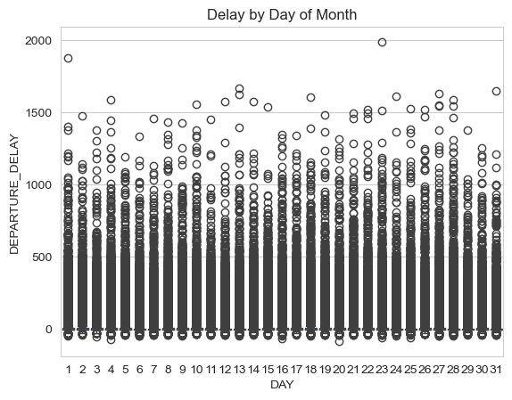

```python
plt.figure()
sns.boxplot(x='DAY', y='DEPARTURE_DELAY', data=df)
plt.title('Delay by Day of Month')
plt.show()
```

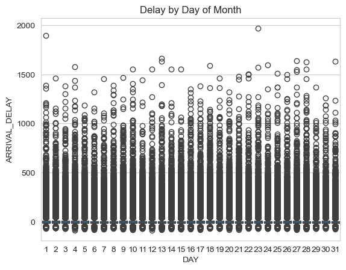

```python
plt.figure()
sns.boxplot(x='DAY', y='ARRIVAL_DELAY', data=df)
plt.title('Delay by Day of Month')
plt.show()
```

### Insight

given the amount of outliers and size I have decided to cap the outliers at 600 as any more than that and the next flight would most likely be canceled impacting analysis

```python
#code to cap departure delay and arrival delay
bad_idx = df.index[(df['DEPARTURE_DELAY'] >= 600) | (df['ARRIVAL_DELAY'] >= 600)]
df.drop(index=bad_idx, inplace=True)
```

[figure not shown]

```python
plt.figure()
sns.boxplot(x='DAY', y='ARRIVAL_DELAY', data=df)
plt.title('Delay by Hour of Day')
plt.show()
```

### INSIGHTS

There are much less extreme outliers with this corrections

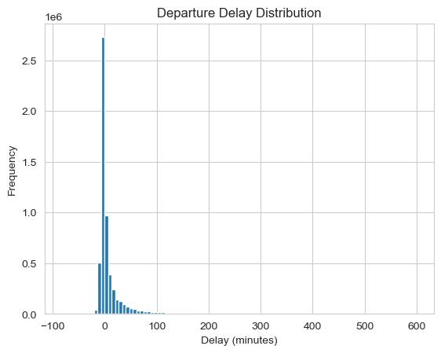

```python
df['DEPARTURE_DELAY'].hist(bins=100)
plt.title("Departure Delay Distribution")
plt.xlabel("Delay (minutes)")
plt.ylabel("Frequency")
plt.show()
```

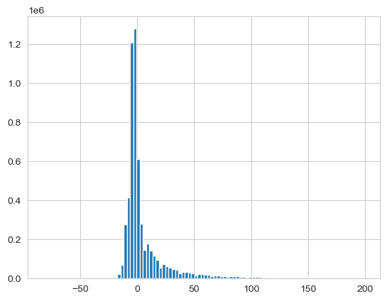

```python
df[df['DEPARTURE_DELAY'] < 200]['DEPARTURE_DELAY'].hist(bins=100)
```

### INSIGHTS

Highly Right skewed data

A majority of flights have no delay or are early

The longer the delay the less likely it is with being very rare over 100 min delay

```python
df['delay_indicator'].value_counts(normalize=True)
```

```
delay_indicator
0    0.822928
1    0.177072
Name: proportion, dtype: float64
```

### INSIGHT

Only 17.7% have a delay greater than 15 min

## Turnaround time vs delay

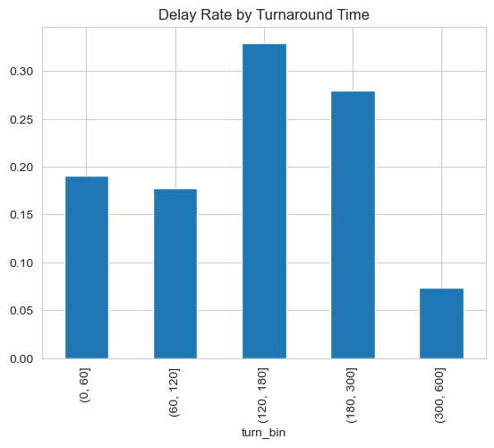

```python
df['turn_bin'] = pd.cut(df['turnaround_time'], bins=[0,60,120,180,300,600])

df.groupby('turn_bin')['delay_indicator'].mean().plot(kind='bar')
plt.title("Delay Rate by Turnaround Time")
```

### Insight

Inverted U shape correlation between turnaround time and delay

## Delay Propogation

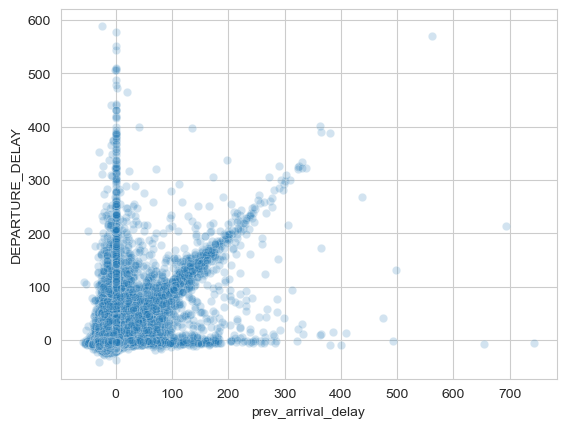

```python
sns.scatterplot(
    x='prev_arrival_delay',
    y='DEPARTURE_DELAY',
    data=df.sample(50000),
    alpha=0.2
)
```

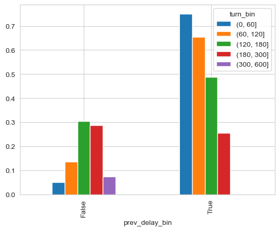

```python
df['prev_delay_bin'] = df['prev_arrival_delay'] > 15

df.groupby(['prev_delay_bin','turn_bin'], observed=True)['delay_indicator'].mean().unstack().plot(kind='bar')
```

### Insight

Delay propagation is strongest when turnaround time is short, and weakens as turnaround increases

## Airport congestion effect

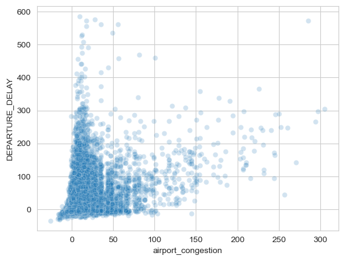

```python
sns.scatterplot(
    x='airport_congestion',
    y='DEPARTURE_DELAY',
    data=df.sample(50000),
    alpha=0.2
)
```

### Insights

There is a positive relationship between airport congestion and departure delay but it does not seem to be strictly linear

## Time-of-day effects

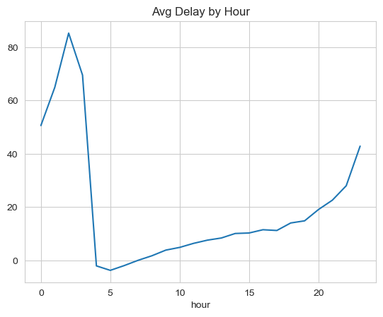

```python
df.groupby('hour')['DEPARTURE_DELAY'].mean().plot()
plt.title("Avg Delay by Hour")
```

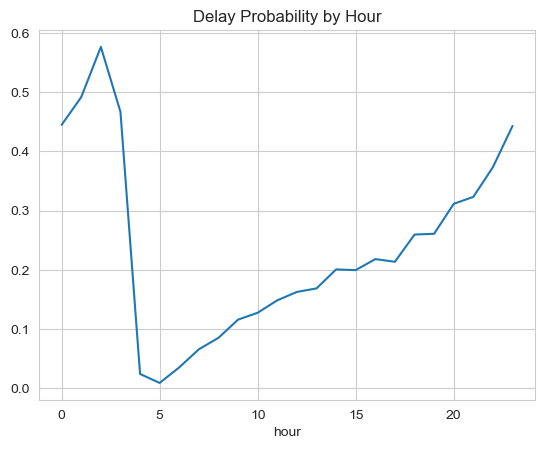

```python
df.groupby('hour')['delay_indicator'].mean().plot()
plt.title("Delay Probability by Hour")
```

### Insights

Delay is significantly more likely in the middle of the night but seem to stack up as the day goes on indicating the delay propogation

## Day of Week patterns

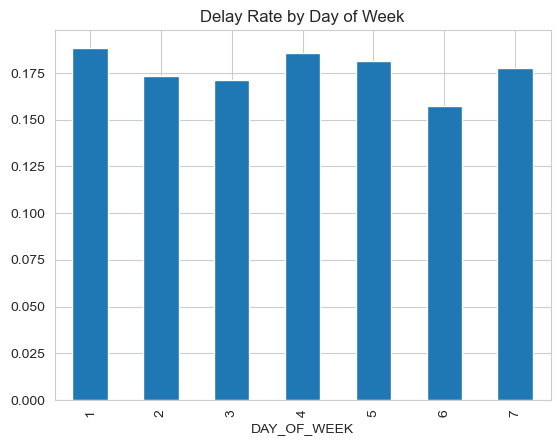

```python
df.groupby('DAY_OF_WEEK')['delay_indicator'].mean().plot(kind='bar')
plt.title("Delay Rate by Day of Week")
```

### Insight

Delay seems fairly stable througout the week

## What causes delay (decomposition)

```python
df[['AIR_SYSTEM_DELAY','AIRLINE_DELAY','WEATHER_DELAY','SECURITY_DELAY']].mean()
```

```
AIR_SYSTEM_DELAY    2.494472
AIRLINE_DELAY       3.380445
WEATHER_DELAY       0.521808
SECURITY_DELAY      0.014145
dtype: float64
```

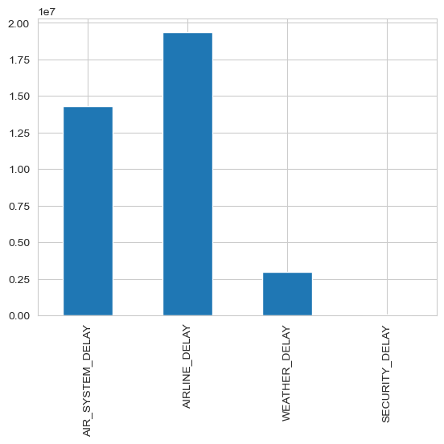

```python
df[['AIR_SYSTEM_DELAY','AIRLINE_DELAY','WEATHER_DELAY','SECURITY_DELAY']].sum().plot(kind='bar')
```

### INSIGHTS

Most delay is airline/system, not weather or security

## Airlines

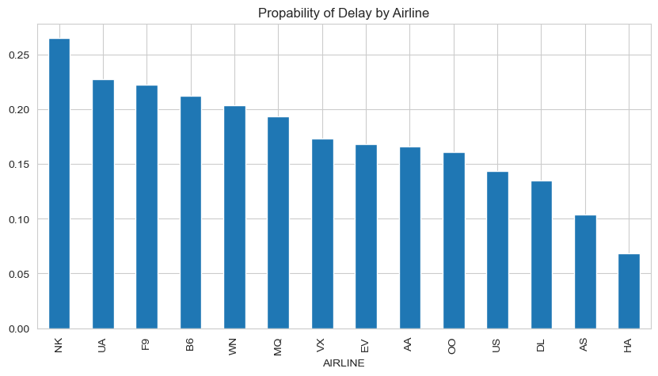

```python
airline_delay = df.groupby('AIRLINE')['delay_indicator'].agg(['mean','count'])
airline_delay = airline_delay.sort_values('mean', ascending=False)

airline_delay['mean'].plot(kind='bar', figsize=(10,5), title='Propability of Delay by Airline')
```

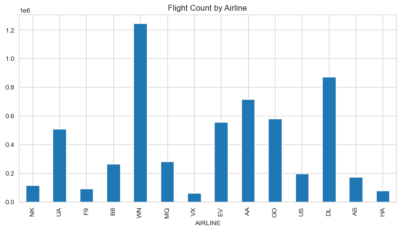

```python
airline_delay['count'].plot(kind='bar', figsize=(10,5), title='Flight Count by Airline')
```

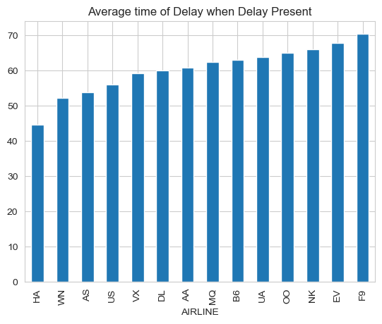

```python
df[df['delay_indicator']==1].groupby('AIRLINE')['DEPARTURE_DELAY'].mean().sort_values().plot(kind='bar', title='Average time of Delay when Delay Present')
```

### Insights

This is a decent amount of differences between airlines in how likely they are to have delays

## 7. Correlation Heatmap

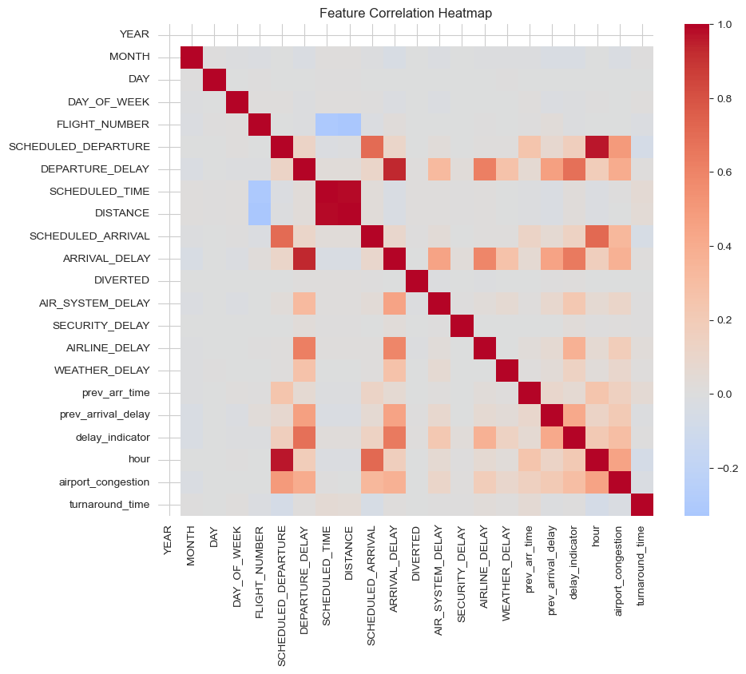

```python
features = df.select_dtypes(include=[np.number])

plt.figure(figsize=(10,8))
sns.heatmap(features.corr(), cmap='coolwarm', center=0)
plt.title('Feature Correlation Heatmap')
plt.show()
```

### Insights

Delay propagation seems likely given the correlation between previous arrival delay and departure delay / delay_indicator Good Idea to only use either Departure delay or Arrival delay in analysis as they are so related(probably departure delay as that matters more) Propopaly good idea to only keep one of sceduled arrival and scheduled departure and scheduled time and distance **IMPORTANT - Weather, Security, Air_system, Airline delays are parts of the total delay time so can not be used to determine what caused it**

```python
df.to_csv("cleaned_flight_data.csv", index=False)
```

## 8. Propagation Statistics

```python
corr = df['prev_arrival_delay'].corr(df['DEPARTURE_DELAY'])
print('Correlation inbound vs outbound delay:', corr)

cond_prob = df[df['prev_arrival_delay'] > 15]['delay_indicator'].mean()
print('P(outbound delay | inbound delay >15):', cond_prob)

p_no_prev_delay = df[df['prev_arrival_delay'] <= 15]['delay_indicator'].mean()
print('P(outbound delay | No inbound delay >15):', p_no_prev_delay)
```

```
Correlation inbound vs outbound delay: 0.4690935566221489
P(outbound delay | inbound delay >15): 0.7044386676154228
P(outbound delay | No inbound delay >15): 0.10345803612020323
```

### Insights:

When inbound flights are delayed outbound delay jumps from 10% to 70% showing a clear indication of delay propogation

Additionally the smaller correlation between the two could indicate that they have non-linear relationship

# Overall Explanation and Takeaways from EDA and Data Prep

During this project we first decided to a few key preprocessing steps. These included handling missing values,and capping extreme delays to reduce distortion. One of the data prep steps that was challenging was ensuring accurate time-based calculations, as initial use of HHMM arithmetic produced incorrect turnaround values. This required converting to true datetime objects and carefully handling edge cases such as overnight flights. Another major challenge was correctly linking flights at the aircraft level. Using simple sorting and shifting initially led to mismatched “previous flights,” resulting in impossible negative turnaround times. This required additional validation logic to ensure that only valid prior flights were used, and to reset or filter cases where sequencing was incorrect. These issues highlighted how sensitive the analysis was to proper temporal alignment and data integrity.

After preprocessing we did Feature engineering. The focus here was on getting derived variables such as previous flight delays, turnaround time, time-of-day effects(hour variable) and a congestion metric based on average delay by airport and hour.

Finally after feature enineering we moved on to EDA which was able to show some important insights that will help with modeling. Most notably, delay propagation is a dominant factor: flights with a delayed inbound aircraft had about a 70% chance of departing late, compared to only about 10% otherwise. Turnaround time seem to exhibit a nonlinear relationship with delays, with moderate turnaround windows showing the highest delay risk, while long turnarounds allowed for recovery. Airline-level differences were substantial, with delay probabilities varying widely, indicating that operational strategies and network structures seem to play a major role. Additionally, airport congestion emerged as a key factor to consider in model building, while weather and security seem to show that they will not be as impactful in final analysis.